# cfMeDIP-seq Evolution

# 10. Evolution Summary

## Timeline of Innovation

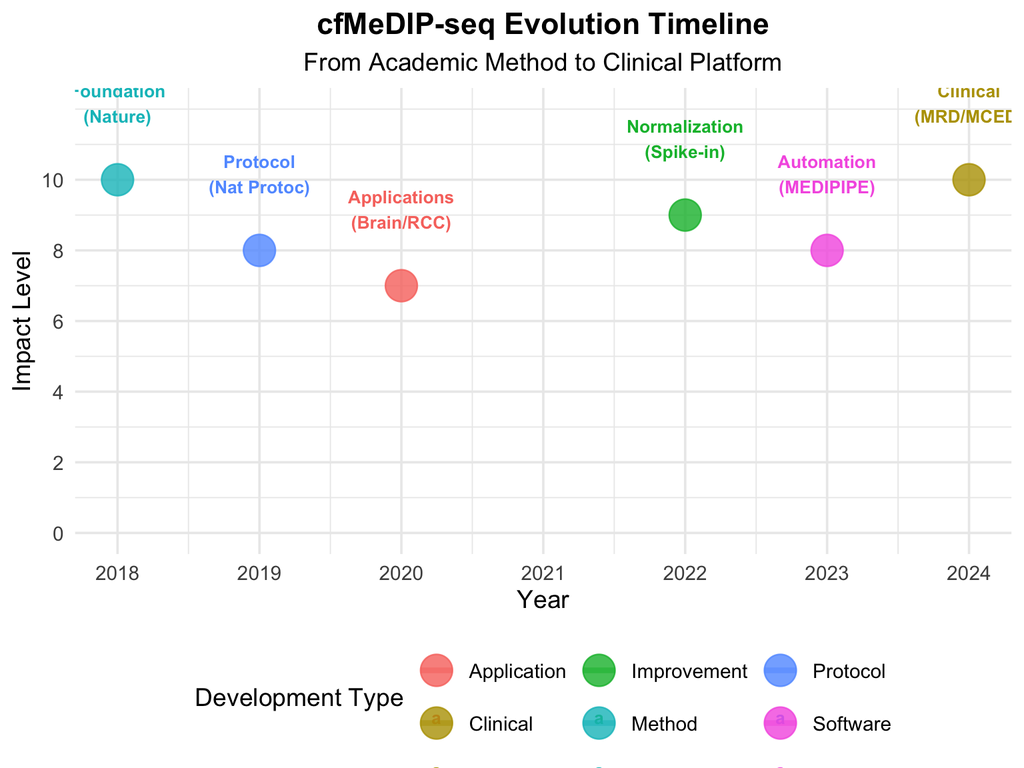

## Key Takeaways

**Technical Evolution:**

1. Low-input cfDNA methodology (1-10 ng) enables liquid biopsy
2. Spike-in normalization reduces batch effects from 5% to <1%
3. MEDIPIPE automation standardizes analysis across labs
4. Multiple classifier approaches validated for different applications

**Platform Advantages:**

- Preserves DNA integrity (no bisulfite)
- Genome-wide discovery capability
- Flexible classifier development
- Single assay, multiple applications

**Clinical Translation:**

- MRD: Validated in head & neck, lung cancer
- MCED: 12 cancers in development, 50+ planned
- Performance: 92-97% sensitivity across stages

## Future Outlook

**Near-Term (1-2 years):**

- Complete CAMPERR study validation
- Expand MRD to additional cancer types
- Regulatory pathway progress

**Mid-Term (3-5 years):**

- FDA approval for MRD applications
- MCED clinical utility demonstration
- Integration into standard care pathways

**Long-Term (5+ years):**

- Population screening programs
- Multi-omics integration (cfDNA + protein)
- Personalized treatment monitoring

> From research tool to standard of care

# Conclusions

## Summary

cfMeDIP-seq has evolved from an academic methylation profiling method to a clinically-validated platform for cancer detection and monitoring.

**Key Milestones:**

- ✓ Foundational methodology (2018)
- ✓ Standardized protocol (2019)
- ✓ Variability mitigation (2022)
- ✓ Computational automation (2023)
- ✓ Clinical validation (2024)

**Enabling Factors:**

- Low DNA input requirements
- Genome-wide coverage
- Platform flexibility
- Robust normalization strategies

## Questions?

### Additional Resources

**Comprehensive Documentation:**

- Protocol: Shen et al., *Nat Protoc* 2019
- Pipeline: `github.com/pughlab/MEDIPIPE`
- Reviews: Multiple disease-specific validations

**Data Access:**

- Public: GEO, Zenodo
- Controlled: EGA (patient data)

*Presentation based on comprehensive technical review (January 2026)*

**Disclaimer:** Information for research and educational purposes. Clinical decisions should be made in consultation with healthcare providers.